# Homework 3 MSDS6372

Ben Goodwin

1/27/2021

## Part 1, Conceptual Questions

Question 1 Response: Assumption 1: The populations from which the samples were obtained must be normally distributed or at least approximately normally distributed. Assumption 2: The samples must be independent. Assumption 3: The variances of the population must be equal Assumption 4: The groups must have equal sample sizes

Question 2 Response: I like to think of interactions as an effect that happens when one of the explanatory variables interacts with another variable on a response variable. A good example is found at https://www.statisticshowto.com/interaction-effect-interacting-variable/ and uses the effect of a diet drink on weight loss, and the effect of the diet pill on weight loss. With the interaction happening when the drink and pill are taken at the same time. It seems plausible that the combination of the two could speed up weight loss, or even low it down. This is an example of an interaction effect.

Question 3 Response: Family-wise error rates are the probability of a type-I error. These are also known as false discoveries and occur when performing multiple hypothesis tests. In multiple testing it becomes an issue (For ANOVA/Two-Way ANOVA) because we are testing multiple hypotheses and typically each has an ${\alpha}$ level of 0.05, but since we are performing multiple tests we have to multiply this across all of our tests, so we have to reduce the overall level!

Question 4 Response: False- Type III tests for the presence of a main effect after the other main effect an interaction.

## Exercise 1

```r
ACT<-read.csv("MathACT.csv")
#Attaching the data set, creating a function, and creating a summary stats table.  Note: In line 44 below, you can add other statistics like median, IQR,etc.
attach(ACT)
mysummary<-function(x){
  result<-c(length(x),mean(x),sd(x),sd(x)/length(x))
  names(result)<-c("N","Mean","SD","SE")
  return(result)
}
sumstats<-aggregate(Score~Background*Sex,data=ACT,mysummary)
sumstats<-cbind(sumstats[,1:2],sumstats[,-(1:2)])
sumstats
```

```
##   Background    Sex   N      Mean       SD         SE
## 1          a female  82  9.073171 4.186340 0.05105293
## 2          b female 387 13.963824 5.000905 0.01292224
## 3          c female  54 24.629630 4.849806 0.08981122
## 4          a   male  48 11.458333 5.086312 0.10596483
## 5          b   male 223 15.565022 4.888305 0.02192065
## 6          c   male  67 25.432836 5.554752 0.08290675
```

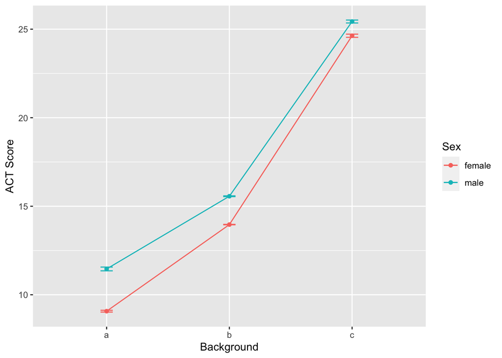

```r
library(ggplot2)
ggplot(sumstats,aes(x=Background,y=Mean,group=Sex,colour=Sex))+
  ylab("ACT Score")+
  geom_line()+
  geom_point()+
  geom_errorbar(aes(ymin=Mean-SE,ymax=Mean+SE),width=.1)
```

## Homework Questions, Exercise 1

```r
#Question 1, Modify the previous R script so that the summary table also includes the min, the max, and IQR.
mysummary<-function(x){
  result<-c(length(x),mean(x),sd(x),sd(x),min(x),max(x),IQR(x)/length(x))
  names(result)<-c("N","Mean","SD","SE","Min","Max","IQR")
  return(result)
}
sumstats2<-aggregate(Score~Background*Sex,data=ACT,mysummary)
sumstats2<-cbind(sumstats[,1:2],sumstats[,-(1:2)])
sumstats2
```

```
##   Background    Sex   N      Mean       SD         SE
## 1          a female  82  9.073171 4.186340 0.05105293
## 2          b female 387 13.963824 5.000905 0.01292224
## 3          c female  54 24.629630 4.849806 0.08981122
## 4          a   male  48 11.458333 5.086312 0.10596483
## 5          b   male 223 15.565022 4.888305 0.02192065
## 6          c   male  67 25.432836 5.554752 0.08290675
```

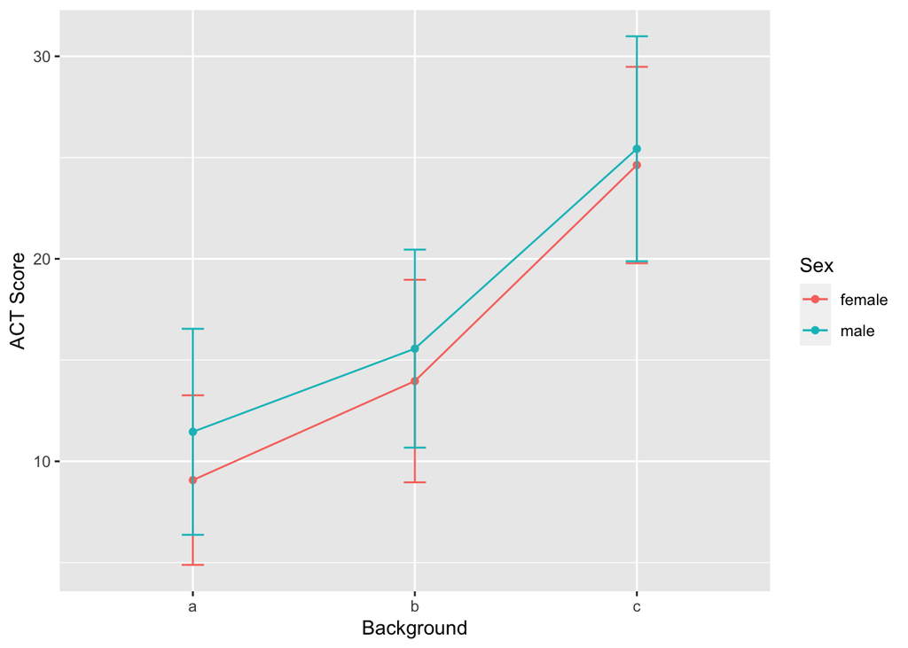

```r
#Question 2, Create another means plot but rather than using the standard errors (SE) to make the error bars.  Make it with the raw standard deviations (SD).  Which graphic (compared to plot using SE) is more telling about the assumption of equal variances for the ANOVA model?  Give a little explanation for your answer.

ggplot(sumstats,aes(x=Background,y=Mean,group=Sex,colour=Sex))+
  ylab("ACT Score")+
  geom_line()+
  geom_point()+
  geom_errorbar(aes(ymin=Mean-SD,ymax=Mean+SD),width=.1)
```

I think that the SD plot is more telling about the assumption of equal variances for the ANOVA model. Each answer useful questions, either about the population spread or the quality of the estimate of the mean. Personally, I think that either could be argued like many things in statistics. However, the SD plot shows more evidence of variance and should be fully considered. And while this may make us break away from our perfect assumptions, we need to evaluate all assumptions whether or not they agree with our intended statistical goals.

## Exercise 2

The following code fits the nonadditive two way anova model and then produces the first the main residual diagnostics for assumption checking. The syntax for including interaction terms is slightly different so please make note.

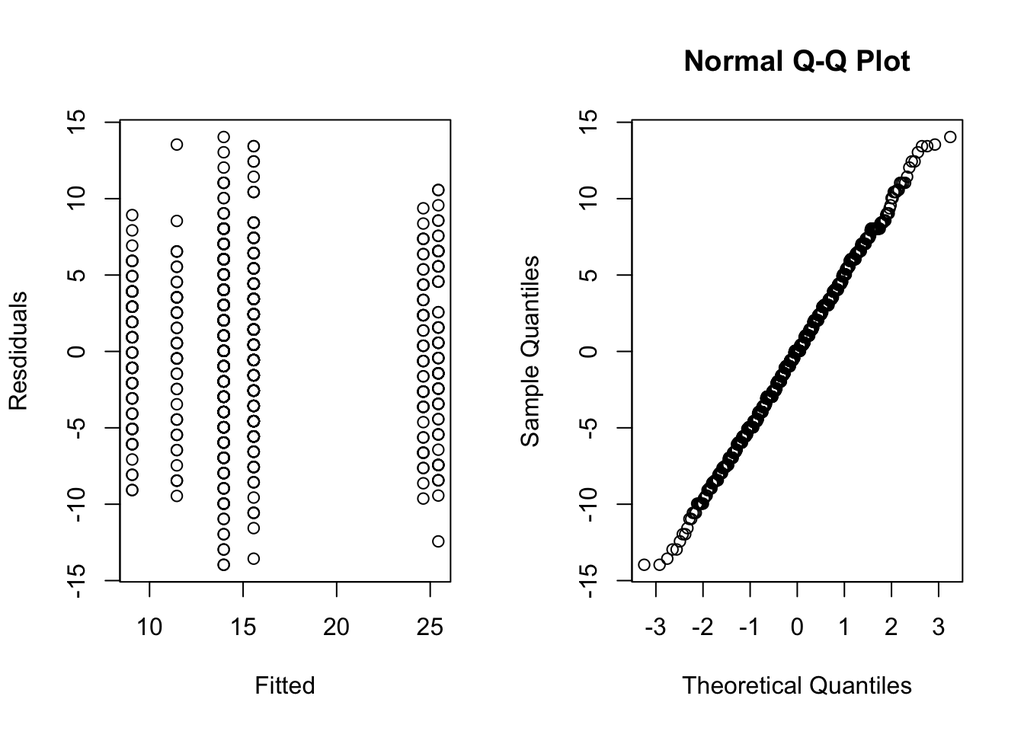

```r
model.fit<-aov(Score~Background+Sex+Background:Sex,data=ACT)
par(mfrow=c(1,2))
plot(model.fit$fitted.values,model.fit$residuals,ylab="Resdiduals",xlab="Fitted")
qqnorm(model.fit$residuals)
```

The previous graphics are not very pretty. We can use the ggplot2 package to jazz things up a bit.

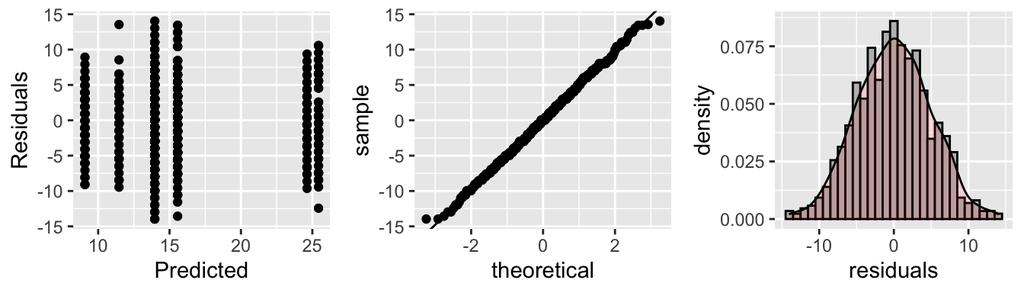

```r
library(gridExtra)
myfits<-data.frame(fitted.values=model.fit$fitted.values,residuals=model.fit$residuals)
#Residual vs Fitted
plot1<-ggplot(myfits,aes(x=fitted.values,y=residuals))+ylab("Residuals")+
  xlab("Predicted")+geom_point()
#QQ plot of residuals  #Note the diagonal abline is only good for qqplots of normal data.
plot2<-ggplot(myfits,aes(sample=residuals))+
  stat_qq()+geom_abline(intercept=mean(myfits$residuals), slope = sd(myfits$residuals))
#Histogram of residuals
plot3<-ggplot(myfits, aes(x=residuals)) +
  geom_histogram(aes(y=..density..),binwidth=1,color="black", fill="gray")+
  geom_density(alpha=.1, fill="red")
grid.arrange(plot1, plot2,plot3, ncol=3)
```

As discussed in class, the residual diagnostics do not provide any concern about the assumptions of a two way anova analysis. If there were, we would have to address those concerns via a transformation of the response or multiple analysis with and without outlines, etc. Examining the type-III sums of squares F table we have:

```r
library(car)
Anova(model.fit,type=3)
```

```
## Anova Table (Type III tests)
##
## Response: Score
##                 Sum Sq  Df  F value    Pr(>F)
## (Intercept)     6750.4   1 276.4610 < 2.2e-16 ***
## Background      8045.8   2 164.7564 < 2.2e-16 ***
## Sex              172.2   1   7.0542  0.008055 **
## Background:Sex    37.6   2   0.7709  0.462898
## Residuals      20876.8 855
## ---
## Signif. codes:  0 '***' 0.001 '**' 0.01 '*' 0.05 '.' 0.1 ' ' 1
```

Writing contrasts are a little more cumbersome in R. To help you guys out and alleviate the need to keep track of all of the zero’s and one’s, I’ve wrote a little script that allows you to just specify the contrast that you want in a slightly simpler way. But first lets use some tools that provides a blanket lists of comparisons. Since there is no significant interaction, we just need to examine each factor one at a time. To examine all pairwise comparisons for say “background”, the following script provides the t-test results adjusted for multiple tests using Tukey’s procedure.

```r
TukeyHSD(model.fit,"Background",conf.level=.95)
```

```
##   Tukey multiple comparisons of means
##     95% family-wise confidence level
##
## Fit: aov(formula = Score ~ Background + Sex + Background:Sex, data = ACT)
##
## $Background
##          diff       lwr       upr p adj
## b-a  4.595334  3.474636  5.716033     0
## c-a 15.120534 13.655047 16.586021     0
## c-b 10.525200  9.370655 11.679744     0
```

The table is helpful for quickly examining the results and getting the p-values and estimates. Its always helpful to visualize.

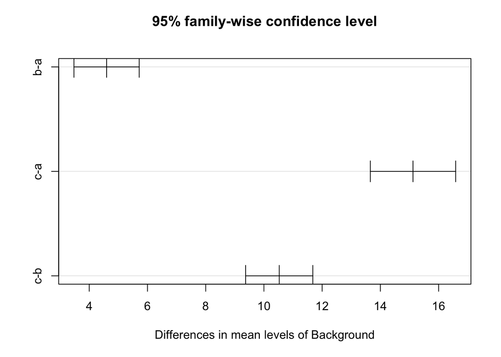

```r
plot(TukeyHSD(model.fit,"Background",conf.level=.95))
```

If an interaction is present, you can rinse and repeat the code just using the interaction term instead. This code below is for illustration, it makes no sense to do this on the ACT data set since the interaction F test is not significant.

```r
TukeyHSD(model.fit,"Background:Sex",conf.level=.95)
```

```
##   Tukey multiple comparisons of means
##     95% family-wise confidence level
##
## Fit: aov(formula = Score ~ Background + Sex + Background:Sex, data = ACT)
##
## $`Background:Sex`
##                          diff         lwr        upr     p adj
## b:female-a:female   4.8906536   3.1748785   6.606429 0.0000000
## c:female-a:female  15.5564589  13.0830154  18.029902 0.0000000
## a:male-a:female     2.3851626  -0.1797967   4.950122 0.0854058
## b:male-a:female     6.4918517   4.6691025   8.314601 0.0000000
## c:male-a:female    16.3596651  14.0354027  18.683927 0.0000000
## c:female-b:female  10.6658053   8.6155720  12.716039 0.0000000
## a:male-b:female    -2.5054910  -4.6652479  -0.345734 0.0123022
## b:male-b:female     1.6011981   0.4146282   2.787768 0.0017335
## c:male-b:female    11.4690115   9.6014652  13.336558 0.0000000
## a:male-c:female   -13.1712963 -15.9710443 -10.371548 0.0000000
## b:male-c:female    -9.0646072 -11.2051648  -6.924050 0.0000000
## c:male-c:female     0.8032062  -1.7778339   3.384246 0.9492008
## b:male-a:male       4.1066891   1.8610087   6.352369 0.0000033
## c:male-a:male      13.9745025  11.3056335  16.643371 0.0000000
## c:male-b:male       9.8678134   7.9015327  11.834094 0.0000000
```

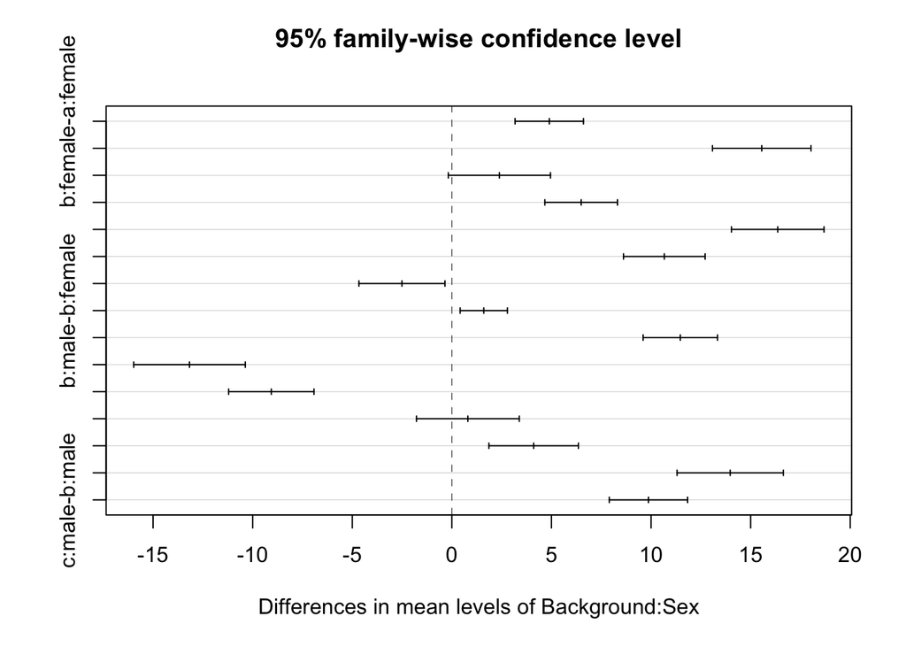

```r
plot(TukeyHSD(model.fit,"Background:Sex",conf.level=.95))
```

As discussed in class, including all possible combinations of comparisons may be too much and of little interest to the actual study at hand. We can manually create the comparisons of interest and manual adjust the p-values through writing contrasts. To help streamline this for you guys, I’ve included a little R script that makes the process a little more automated for you.

The following script allow you to write out your contrasts in a more verbal syntax. I’ll run you through the most tedious scenario. The script can be easily modified to handle simpler situations. First things first, all you need to do is provide some details as to what comparisons you’d like to make. Suppose, that if the interaction was significant, the only meaningful comparisons to make in the analysis comparing males versus females for each level of background.

```r
library(lsmeans) #maybe need eemeans package
contrast.factor<-~Background*Sex
mycontrast<-c("amale-afemale","bmale-bfemale","cmale-cfemale")
dat<-ACT
```

## Homework Question

1. Consider comparing the mean ACT scores of males versus females specifically for background A. Compare the outputs from the Tukey comparison result table to that of the output generated from my manual contrast maker. Is the estimated differences the same? Can you explain why are the adjusted p-values different for the two result tables? One would suggest that we reject the null while the other would have us to fail to reject. (This is just a conceptual thinking question. The interaction term is not significant for this data analysis.)

Background Sex diff lwr upr p adj a:male-a:female 2.3851626 -0.1797967 4.950122 0.0854058

Contrast Estimate SE DF t.ratiopval bonf amale-afemale 2.3851626 0.8980349 855 2.656 0.0081 0.0241653060

## Exercise 3

```r
library(Sleuth3)
head(ex1317)
```

```
##   Iridium    Strata DepthCat
## 1      75 Limestone        1
## 2     200 Limestone        1
## 3     120 Limestone        2
## 4     310 Limestone        2
## 5     290 Limestone        3
## 6     450 Limestone        3
```

## Question 1, Provide a means plot of the data. Use this along with any additional information to comment on whether an addative or nonadditive model is probably the most appropriated. If it is not obvious that is okay just do your best.

```r
mysummary<-function(x){
  result<-c(length(x),mean(x),sd(x),sd(x),min(x),max(x),IQR(x)/length(x))
  names(result)<-c("N","Mean","SD","SE","Min","Max","IQR")
  return(result)
}
sumstats2<-aggregate(Iridium~DepthCat*Strata,data=ex1317,mysummary)
sumstats2<-cbind(sumstats2[,1:2],sumstats2[,-(1:2)])
sumstats2
```

```
##    DepthCat    Strata N      Mean        SD        SE Min Max      IQR
## 1         1 Limestone 2 137.50000  88.38835  88.38835  75 200 31.25000
## 2         2 Limestone 2 215.00000 134.35029 134.35029 120 310 47.50000
## 3         3 Limestone 3 453.33333 165.02525 165.02525 290 620 55.00000
## 4         4 Limestone 3 211.66667  45.36886  45.36886 170 260 15.00000
## 5         5 Limestone 2 127.50000  10.60660  10.60660 120 135  3.75000
## 6         6 Limestone 3  66.66667  53.92897  53.92897   5 105 16.66667
## 7         1     Shale 2 305.50000 276.47875 276.47875 110 501 97.75000
## 8         2     Shale 1 315.00000        NA        NA 315 315  0.00000
## 9         3     Shale 2 792.50000 116.67262 116.67262 710 875 41.25000
## 10        4     Shale 1 400.00000        NA        NA 400 400  0.00000
## 11        5     Shale 5 165.00000  70.71068  70.71068 120 290  4.00000
## 12        6     Shale 2 180.00000  49.49747  49.49747 145 215 17.50000
```

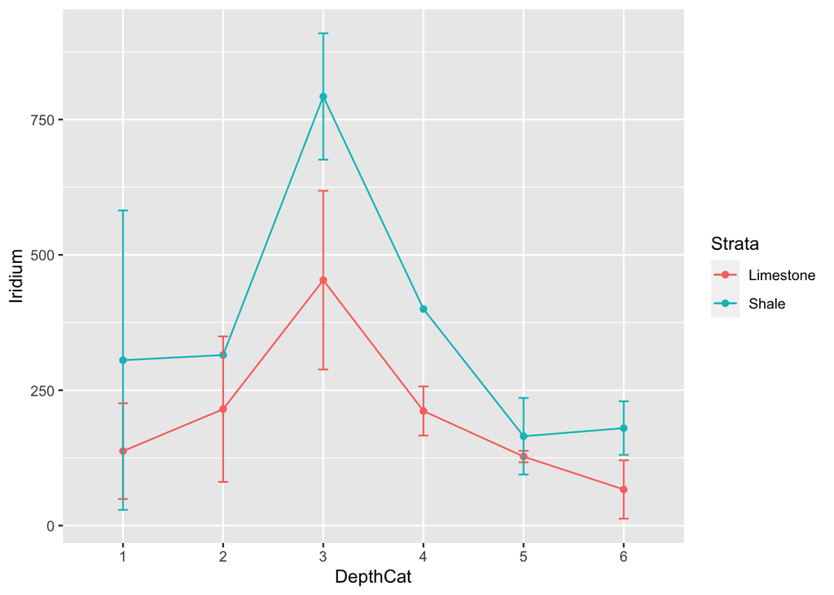

```r
ggplot(sumstats2,aes(x=DepthCat,y=Mean,group=Strata,colour=Strata))+
  ylab("Iridium")+
  geom_line()+
  geom_point()+
  geom_errorbar(aes(ymin=Mean-SE,ymax=Mean+SE),width=.1)
```

## Question 2, Fit a nonadditive 2 way anova model to the data set and provide the residual diagnostics. Comment on the appropriateness of the current anova fit.

```r
ex1317$Iridium <- as.integer(ex1317$Iridium)
nonadd <- aov(Iridium~DepthCat*Strata,data=ex1317)
summary(nonadd)
```

```
##                 Df Sum Sq Mean Sq F value   Pr(>F)
## DepthCat         5 735267  147053  11.597 7.34e-05 ***
## Strata           1 151433  151433  11.943  0.00325 **
## DepthCat:Strata  5  65523   13105   1.033  0.43144
## Residuals       16 202878   12680
## ---
## Signif. codes:  0 '***' 0.001 '**' 0.01 '*' 0.05 '.' 0.1 ' ' 1
```

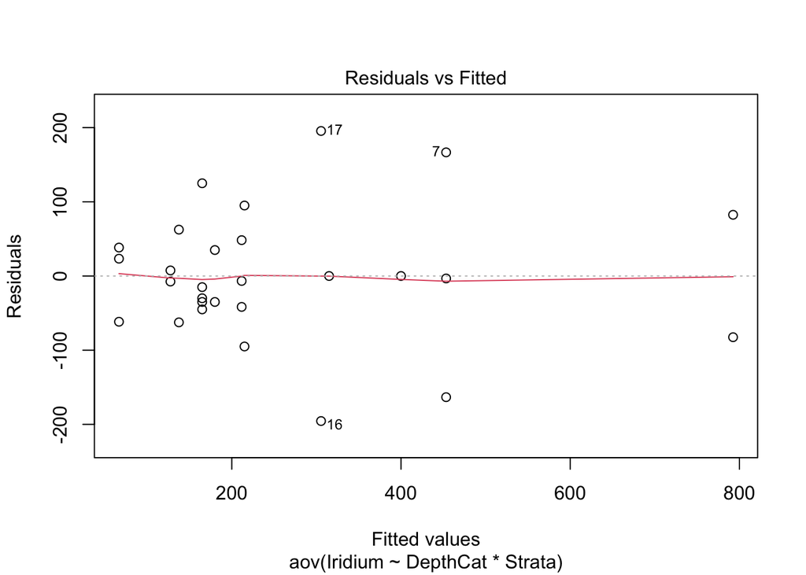

```r
#1) Homogeneity of variances
plot(nonadd,1)
```

```r
leveneTest(Iridium~DepthCat*Strata,data=ex1317)
```

```
## Levene's Test for Homogeneity of Variance (center = median)
##       Df F value  Pr(>F)
## group 11  2.4358 0.05157 .
##       16
## ---
## Signif. codes:  0 '***' 0.001 '**' 0.01 '*' 0.05 '.' 0.1 ' ' 1
```

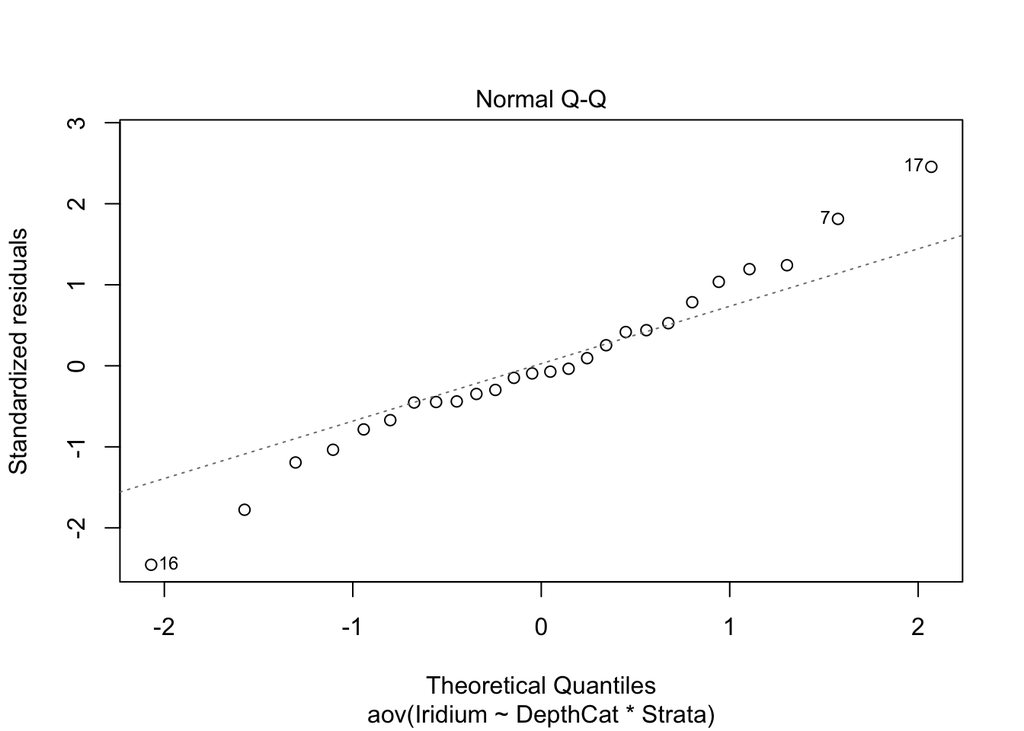

```r
#Homogeneity of variance can be assumed


#2) Normality
plot(nonadd,2)
```

```r
#This seems to follow a general normal distribution
```

## Question 3, Provide the type 3 ANOVA F-tests. Answer the following question using the table. Do the potential changes in mean Iridium by strata depend on the depth?

```r
Anova(nonadd,type=3)
```

```
## Anova Table (Type III tests)
##
## Response: Iridium
##                 Sum Sq Df F value  Pr(>F)
## (Intercept)      37812  1  2.9821 0.10344
## DepthCat        263448  5  4.1554 0.01306 *
## Strata           28224  1  2.2259 0.15517
## DepthCat:Strata  65523  5  1.0335 0.43144
## Residuals       202878 16
## ---
## Signif. codes:  0 '***' 0.001 '**' 0.01 '*' 0.05 '.' 0.1 ' ' 1
```

We reject the null hypothesis of equal population means and conclude that there is a significant difference Iridium means. The F value is 4.1554, with a p-value of 0.01306.

## Question 4, Using multple testing techniques, determine what factors (or combinations) contribute to changes in mean iridium.

```r
TukeyHSD(nonadd,"DepthCat:Strata",conf.level=.95)
```

```
##   Tukey multiple comparisons of means
##     95% family-wise confidence level
##
## Fit: aov(formula = Iridium ~ DepthCat * Strata, data = ex1317)
##
## $`DepthCat:Strata`
##                                diff         lwr        upr     p adj
## 2:Limestone-1:Limestone   77.500000  -348.62306  503.62306 0.9998289
## 3:Limestone-1:Limestone  315.833333   -73.16202  704.82869 0.1731727
## 4:Limestone-1:Limestone   74.166667  -314.82869  463.16202 0.9997334
## 5:Limestone-1:Limestone  -10.000000  -436.12306  416.12306 1.0000000
## 6:Limestone-1:Limestone  -70.833333  -459.82869  318.16202 0.9998270
## 1:Shale-1:Limestone      168.000000  -258.12306  594.12306 0.9227263
## 2:Shale-1:Limestone      177.500000  -344.39203  699.39203 0.9694283
## 3:Shale-1:Limestone      655.000000   228.87694 1081.12306 0.0011042
## 4:Shale-1:Limestone      262.500000  -259.39203  784.39203 0.7427456
## 5:Shale-1:Limestone       27.500000  -329.02013  384.02013 1.0000000
## 6:Shale-1:Limestone       42.500000  -383.62306  468.62306 0.9999996
## 3:Limestone-2:Limestone  238.333333  -150.66202  627.32869 0.5014783
## 4:Limestone-2:Limestone   -3.333333  -392.32869  385.66202 1.0000000
## 5:Limestone-2:Limestone  -87.500000  -513.62306  338.62306 0.9994717
## 6:Limestone-2:Limestone -148.333333  -537.32869  240.66202 0.9365358
## 1:Shale-2:Limestone       90.500000  -335.62306  516.62306 0.9992833
## 2:Shale-2:Limestone      100.000000  -421.89203  621.89203 0.9997208
## 3:Shale-2:Limestone      577.500000   151.37694 1003.62306 0.0039761
## 4:Shale-2:Limestone      185.000000  -336.89203  706.89203 0.9597980
## 5:Shale-2:Limestone      -50.000000  -406.52013  306.52013 0.9999865
## 6:Shale-2:Limestone      -35.000000  -461.12306  391.12306 0.9999999
## 4:Limestone-3:Limestone -241.666667  -589.59469  106.26135 0.3388347
## 5:Limestone-3:Limestone -325.833333  -714.82869   63.16202 0.1475457
## 6:Limestone-3:Limestone -386.666667  -734.59469  -38.73865 0.0228190
## 1:Shale-3:Limestone     -147.833333  -536.82869  241.16202 0.9378144
## 2:Shale-3:Limestone     -138.333333  -630.37786  353.71119 0.9923714
## 3:Shale-3:Limestone      339.166667   -49.82869  728.16202 0.1184980
## 4:Shale-3:Limestone      -53.333333  -545.37786  438.71119 0.9999990
## 5:Shale-3:Limestone     -288.333333  -599.52962   22.86295 0.0826092
## 6:Shale-3:Limestone     -273.333333  -662.32869  115.66202 0.3247402
## 5:Limestone-4:Limestone  -84.166667  -473.16202  304.82869 0.9991533
## 6:Limestone-4:Limestone -145.000000  -492.92802  202.92802 0.8945388
## 1:Shale-4:Limestone       93.833333  -295.16202  482.82869 0.9978151
```

[output cut: 18 more lines]

```
## 2:Shale-1:Shale            9.500000  -512.39203  531.39203 1.0000000
## 3:Shale-1:Shale          487.000000    60.87694  913.12306 0.0182200
## 4:Shale-1:Shale           94.500000  -427.39203  616.39203 0.9998359
## 5:Shale-1:Shale         -140.500000  -497.02013  216.02013 0.9229136
## 6:Shale-1:Shale         -125.500000  -551.62306  300.62306 0.9890968
## 3:Shale-2:Shale          477.500000   -44.39203  999.39203 0.0892737
## 4:Shale-2:Shale           85.000000  -517.62901  687.62901 0.9999857
## 5:Shale-2:Shale         -150.000000  -616.79442  316.79442 0.9793521
## 6:Shale-2:Shale         -135.000000  -656.89203  386.89203 0.9960834
## 4:Shale-3:Shale         -392.500000  -914.39203  129.39203 0.2472265
## 5:Shale-3:Shale         -627.500000  -984.02013 -270.97987 0.0002436
## 6:Shale-3:Shale         -612.500000 -1038.62306 -186.37694 0.0022197
## 5:Shale-4:Shale         -235.000000  -701.79442  231.79442 0.7417976
## 6:Shale-4:Shale         -220.000000  -741.89203  301.89203 0.8878615
## 6:Shale-5:Shale           15.000000  -341.52013  371.52013 1.0000000
```

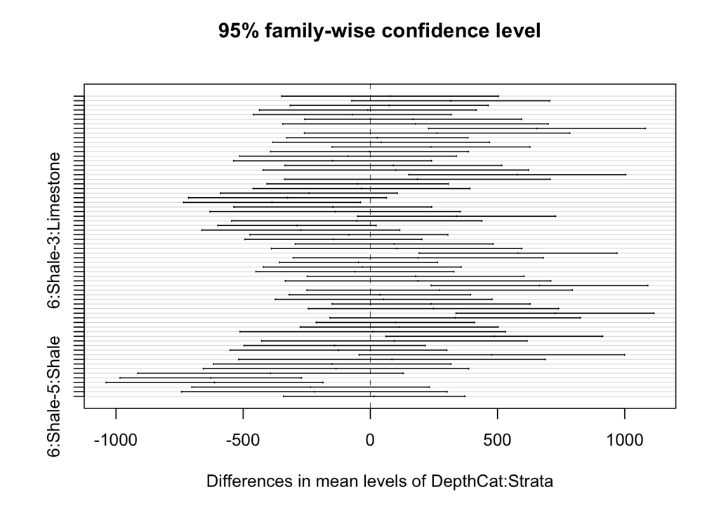

```r
plot(TukeyHSD(nonadd,"DepthCat:Strata",conf.level=.95))
```

```r
TukeyHSD(nonadd,"DepthCat",conf.level=.95)
```

```
##   Tukey multiple comparisons of means
##     95% family-wise confidence level
##
## Fit: aov(formula = Iridium ~ DepthCat * Strata, data = ex1317)
##
## $DepthCat
##           diff        lwr        upr     p adj
## 2-1   26.83333 -250.28273  303.94940 0.9995207
## 3-1  367.50000  124.10617  610.89383 0.0019747
## 4-1   37.25000 -219.30962  293.80962 0.9966677
## 5-1  -67.21429 -294.63008  160.20151 0.9263228
## 6-1 -109.50000 -352.89383  133.89383 0.6984038
## 3-2  340.66667   75.69303  605.64030 0.0082583
## 4-2   10.41667 -266.69940  287.53273 0.9999955
## 5-2  -94.04762 -344.42417  156.32893 0.8257176
## 6-2 -136.33333 -401.30697  128.64030 0.5755951
## 4-3 -330.25000 -573.64383  -86.85617 0.0052350
## 5-3 -434.71429 -647.16584 -222.26274 0.0000766
## 6-3 -477.00000 -706.47390 -247.52610 0.0000636
## 5-4 -104.46429 -331.88008  122.95151 0.6807458
## 6-4 -146.75000 -390.14383   96.64383 0.4136558
## 6-5  -42.28571 -254.73726  170.16584 0.9858783
```

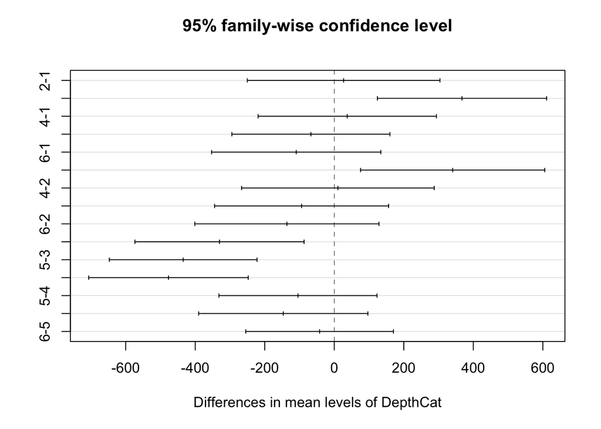

```r
plot(TukeyHSD(nonadd,"DepthCat",conf.level=.95))
```

```r
TukeyHSD(nonadd,"Strata",conf.level=.95)
```

```
##   Tukey multiple comparisons of means
##     95% family-wise confidence level
##
## Fit: aov(formula = Iridium ~ DepthCat * Strata, data = ex1317)
##
## $Strata
##                     diff      lwr     upr     p adj
## Shale-Limestone 139.6393 49.18368 230.095 0.0047881
```

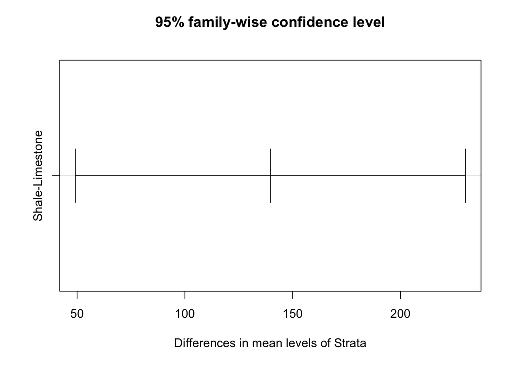

```r
plot(TukeyHSD(nonadd,"Strata",conf.level=.95))
```

And that’s it for this week! -Ben